# Tarea 6: regresión logística

## Regresión logística y regularización

Considera los siguientes datos de entrenamiento donde queremos predecir la categoria y en función de x usando regresión logística, es decir, la probabilidad de que la $y$ sea igual a 1 es igual a:

$$p(x) = h(a + bx)$$

donde $a$ y $b$ son parámetros que queremos ajustar y $h$ es la función sigmoide que vimos en clase.

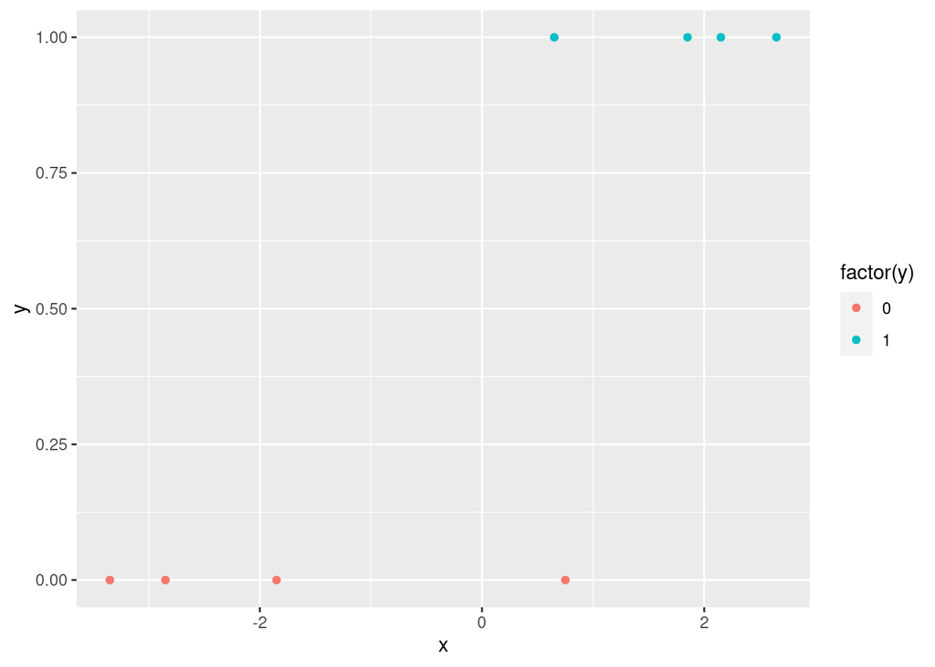

```r
library(tidyverse)
datos_ent_tbl <- tibble(
  x = c(-2, -2.5, -1, 1.5, 1.6, 2.7, 3, 3.5),
  y = c(0, 0, 0, 1, 0, 1, 1, 1)) |>
  mutate(x = x - mean(x)) # centrar x
ggplot(datos_ent_tbl, aes(x = x, y = y, colour = factor(y) )) +
  geom_point()
```

Usaremos estas funciones auxiliares:

```r
h <- function(x){
  1/(1 + exp(-x))
  # o exp(x) / (1 + exp(x)), que es lo mismo
}
perdida_log <- function(p, y){
  -mean(y * log(p) + (1-y)*log(1-p))
}
evaluar_h <- function(x, params){
  a = params[1]
  b = params[2]
  prob <- h(a + b * x)
  tibble(x = x, p = prob)
}
calc_perdida_log <- function(datos){
  perdida_fun <- function(params){
    resultado <- perdida_log(
      p = evaluar_h(x = datos$x, params) |> pull(p),
      y = datos$y)
    resultado
  }
  perdida_fun
}
```

En el siguiente código, podemos proponer coeficientes a y b de regresión logística y ver cómo ajusta el modelo

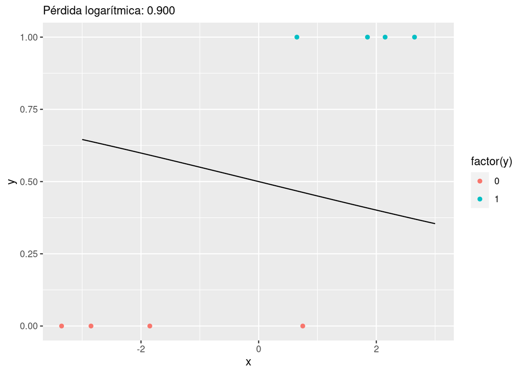

```r
a <- 0
b <- -0.2
perdida_log_ent <- calc_perdida_log(datos_ent_tbl)
modelo_logistico <- evaluar_h(x = seq(-3, 3, 0.01), params = c(a, b))
ggplot(datos_ent_tbl, aes(x = x)) +
  geom_point(aes(y = y, colour = factor(y))) +
  geom_line(data = modelo_logistico, aes(y = p)) +
  labs(subtitle = sprintf("Pérdida logarítmica: %.3f", perdida_log_ent(c(a,b))))
```

*Pregunta 1*: Cambiando los valores de a y b busca minimizar la pérdida logarítmica aproximadamente. ¿Tu solución da probabilidades muy cercanas a 0 y 1 para todos los valores de $x$?

Sugerencia: 1) Cambia uno de los parámetros por una cantidad **no muy grande**. Checa si la pérdida sube o baja. 2) Si baja, entonces regresa a 1 con el otro parámetro. 3) Si no baja, mueve el parámetro en dirección contraria, hasta que la pérdida baje, 4) Repite 1 alternando parámetros.

```r
perdida <- 9999999
best_a <- 999999
best_b <- 99999
for(i in -3:3){
  for(j in -3:3){
    perdida_log_ent <- calc_perdida_log(datos_ent_tbl)
    modelo_logistico <- evaluar_h(x = seq(-3, 3, 0.01), params = c(a, b))
    perdida_log_hist <- perdida_log_ent(c(i, j))
    if(perdida_log_hist < perdida){
      perdida <- perdida_log_hist
      best_a <- i
      best_b <- j
    }
  }
}
print(paste0("El valor de a óptimo es: ", best_a ))
```

```
[1] "El valor de a óptimo es: -2"
```

```r
print(paste0("El valor de b óptimo es: ", best_b))
```

```
[1] "El valor de b óptimo es: 3"
```

```r
print(paste0("La pérdida óptima es: ", perdida))
```

```
[1] "La pérdida óptima es: 0.198436281060796"
```

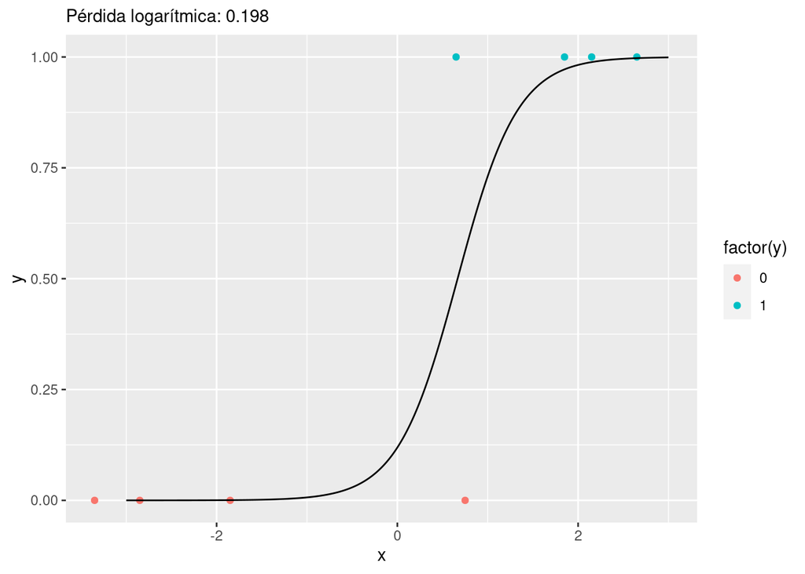

```r
perdida_log_ent <- calc_perdida_log(datos_ent_tbl)
modelo_logistico <- evaluar_h(x = seq(-3, 3, 0.01), params = c(best_a, best_b))
ggplot(datos_ent_tbl, aes(x = x)) +
  geom_point(aes(y = y, colour = factor(y))) +
  geom_line(data = modelo_logistico, aes(y = p)) +
  labs(subtitle = sprintf("Pérdida logarítmica: %.3f", perdida_log_ent(c(best_a,best_b))))
```

**Pregunta 2**: usando el siguiente código o algo similares, encuentra los valores óptimos. ¿Qué optimizador se usa en este caso (consulta la documentación)? ¿Qué tan cercanos son a los valores que encontraste “manualmente” en la pregunta anterior? Si usaste otra función contesta con el optimizador que utiliza esa función.

```r
glm(y ~ x, datos_ent_tbl, family = "binomial")
```

```
Call:  glm(formula = y ~ x, family = "binomial", data = datos_ent_tbl)

Coefficients:
(Intercept)            x
     -2.043        3.035

Degrees of Freedom: 7 Total (i.e. Null);  6 Residual
Null Deviance:      11.09
Residual Deviance: 3.175    AIC: 7.175
```

1. El optimizador que se usa por default es *iteratively reweighted least squares*. b) Los valores que encontré son muy cercanos a los valores que encontró el modelo.

Verifica que un optimizador genérico, para este problema, da la misma solución que la que vimos arriba, minimzando la pérdida logarítmica:

```r
optim(par = c(0, 0), fn = perdida_log_ent)
```

```
$par
[1] -2.042968  3.035148

$value
[1] 0.1984233

$counts
function gradient
      71       NA

$convergence
[1] 0

$message
NULL
```

Sí da la misma solución.

## Regularización

Si queremos hacer regularización, entonces es necesario cambiar la función objetivo que queremos minimizar:

```r
calc_perdida_log_reg <- function(datos, lambda = 0){
  perdida_fun <- function(params){
    resultado <- perdida_log(
      p = evaluar_h(x = datos$x, params) |> pull(p),
      y = datos$y)
    # sumar regularización a la pérdia
    resultado + lambda * params[2] ^2
  }
  perdida_fun
}
```

Seleccionamos un valor de lambda y podemos minimizar:

```r
perdida_log_reg_ent <- calc_perdida_log_reg(datos_ent_tbl, lambda = 0.000001)
optim(par = c(0, 0), fn = perdida_log_reg_ent)
```

```
$par
[1] -2.042179  3.033787

$value
[1] 0.1984325

$counts
function gradient
      71       NA

$convergence
[1] 0

$message
NULL
```

**Pregunta 4**: ¿por qué en el ejemplo anterior obtienes una solución muy similar al de la pregunta anterior (mismos coeficientes)? Incrementa $\lambda$ y describe qué sucede con los coeficientes.

Debido a que la penalización es muy pequeña, castigamos muy poco los valores muy grandes de las betas. Por lo tanto, conforme aumentamos el valor de la lamba la función de pérdida se ve más afectada si los valores de las betas son grandes, por lo que busca ajustar el valor de las betas lo más cercano a $0$ según sea la penalización.

**Pregunta 5** Explica por qué una solución regularizada podría desempeñarse mejor que el modelo que ajustamos sin regularización. Por ejemplo, explica por qué con pocos datos es riesgoso que algunas regiones tengan probabilidades muy cercanas a 0 o 1.

Una solución regularizada implica que podemos controlar mejor las variaciones de los datos muestrales. Si encontramos datos que están muy alejados de la distribución de los demás, esos datos tienen efecto en el cálculo de las betas, por lo que agregar una regularización cuando tenemos pocos datos de entrenamiento nos asegura que no estaremos sobreajustando un modelo.

Al tener pocos datos, tener regiones muy cercanas a probabilidades 0 o 1 hace que el modelo se sobreajuste.

## Regresión logística multinomial

Consideramos un problema de regresión logística multinomial con tres clases, y una sola variable de entrada. Por ejemplo:

```r
datos_tbl <- tibble(
  id = 1:10,
  x = c(-2, -2, -1, 0, 1, 1,5, 2, 3, 3.5),
  clase = c("a", "a", "b", "a", "b", "b", "c", "b", "c", "c"))
datos_tbl
```

```
# A tibble: 10 × 3
      id     x clase
   <int> <dbl> <chr>
 1     1  -2   a
 2     2  -2   a
 3     3  -1   b
 4     4   0   a
 5     5   1   b
 6     6   1   b
 7     7   5   c
 8     8   2   b
 9     9   3   c
10    10   3.5 c
```

Construiremos paso por paso un modelo logístico multinomial. En este caso, escogeremos los parámetros de manera manual, pero más adelante veremos cómo ajustarlos con los datos.

Ponemos para cada clase un predictor lineal:

$f_a(x) = -0.5 - 0.1 x$, $f_b(x) = 0.3 x$, $f_c(x) = 0.6 x$

Que calculamos como sigue:

```r
probas <- datos_tbl |>
  tibble(a = -0.5 - 0.1 * x, b =  0.3 * x, c = 0.6 * x)
probas
```

```
# A tibble: 10 × 6
      id     x clase     a     b     c
   <int> <dbl> <chr> <dbl> <dbl> <dbl>
 1     1  -2   a     -0.3  -0.6   -1.2
 2     2  -2   a     -0.3  -0.6   -1.2
 3     3  -1   b     -0.4  -0.3   -0.6
 4     4   0   a     -0.5   0      0
 5     5   1   b     -0.6   0.3    0.6
 6     6   1   b     -0.6   0.3    0.6
 7     7   5   c     -1     1.5    3
 8     8   2   b     -0.7   0.6    1.2
 9     9   3   c     -0.8   0.9    1.8
10    10   3.5 c     -0.85  1.05   2.1
```

Pero en a, b y c no tenemos probabilidades (por ejemplo hay valores negativos). Según el modelo multinomial, tenemos que obtener el *softmax* de estas cantidades. Primero tomamos exponencial:

```r
probas <- probas |>
  mutate(across(c("a", "b", "c"), ~ exp(.x)))
probas
```

```
# A tibble: 10 × 6
      id     x clase     a     b      c
   <int> <dbl> <chr> <dbl> <dbl>  <dbl>
 1     1  -2   a     0.741 0.549  0.301
 2     2  -2   a     0.741 0.549  0.301
 3     3  -1   b     0.670 0.741  0.549
 4     4   0   a     0.607 1      1
 5     5   1   b     0.549 1.35   1.82
 6     6   1   b     0.549 1.35   1.82
 7     7   5   c     0.368 4.48  20.1
 8     8   2   b     0.497 1.82   3.32
 9     9   3   c     0.449 2.46   6.05
10    10   3.5 c     0.427 2.86   8.17
```

Y ahora normalizamos para que a, b y c sumen 1:

```r
probas <- probas |>
  mutate(suma = a + b + c) |>
  mutate(across(c("a", "b", "c"), ~ .x / suma))
probas
```

```
# A tibble: 10 × 7
      id     x clase      a     b     c  suma
   <int> <dbl> <chr>  <dbl> <dbl> <dbl> <dbl>
 1     1  -2   a     0.466  0.345 0.189  1.59
 2     2  -2   a     0.466  0.345 0.189  1.59
 3     3  -1   b     0.342  0.378 0.280  1.96
 4     4   0   a     0.233  0.384 0.384  2.61
 5     5   1   b     0.147  0.363 0.490  3.72
 6     6   1   b     0.147  0.363 0.490  3.72
 7     7   5   c     0.0148 0.180 0.806 24.9
 8     8   2   b     0.0881 0.323 0.589  5.64
 9     9   3   c     0.0502 0.275 0.675  8.96
10    10   3.5 c     0.0373 0.250 0.713 11.5
```

Y vemos que en cada renglón a, b, y c suman 1. Estas son las probabilidades de nuestro modelo logístico multinomial. Podemos graficarlas:

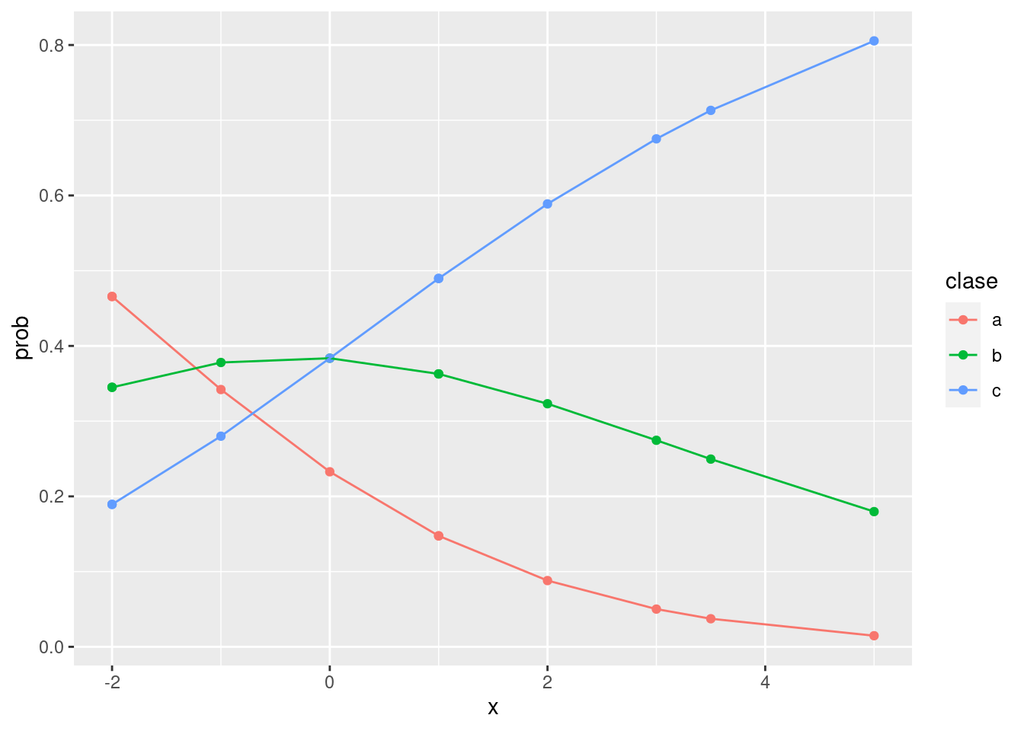

```r
probas |> select(x, a, b, c) |> pivot_longer(c("a", "b", "c"), names_to = "clase", values_to = "prob") |>
  ggplot(aes(x = x, y = prob, colour = clase)) +
  geom_point() + geom_line()
```

**Pregunta 6**: ¿Las probabilidades de cada clase en un modelo logístico multinomial tienen que ser siempre crecientes o decrecientes? Explica por qué no pasa esto, aún cuando las funciones $f_a, f_b, f_c$ son lineales.

Estamos prediciendo probabilidades para múltiples clases, lo que implica que estamos clasificando de acuerdo con ciertas regiones de valores. Por lo tanto, para valores de x donde una la probabilidad se maximiza, el resto de las probabilidades deben ser minimizadas, lo que implica que hay regiones donde las probabilidades son mayores según la definición de la función lineal.

**Pregunta 7**: escribe un modelo que de las mismas probabilidades, pero que tenga $f_c(x) = 0$ para toda $x$ ¿Eso quiere decir que la probabilidad de $c$ no cambia para ninguna $x$?

Sugerencia: empieza calculando:

```r
probas <- datos_tbl |>
  tibble(a = -0.5 - 0.1 * x - 0.6 * x, b =  0.3 * x - 0.6*x, c = 0)
probas
```

```
# A tibble: 10 × 6
      id     x clase     a     b     c
   <int> <dbl> <chr> <dbl> <dbl> <dbl>
 1     1  -2   a      0.9   0.6      0
 2     2  -2   a      0.9   0.6      0
 3     3  -1   b      0.2   0.3      0
 4     4   0   a     -0.5   0        0
 5     5   1   b     -1.2  -0.3      0
 6     6   1   b     -1.2  -0.3      0
 7     7   5   c     -4    -1.5      0
 8     8   2   b     -1.9  -0.6      0
 9     9   3   c     -2.6  -0.9      0
10    10   3.5 c     -2.95 -1.05     0
```

y luego calcula con el código de arriba los probabilidades. Verifica que son iguales.

```r
probas <- probas |>
  mutate(across(c("a", "b", "c"), ~ exp(.x)))
probas
```

```
# A tibble: 10 × 6
      id     x clase      a     b     c
   <int> <dbl> <chr>  <dbl> <dbl> <dbl>
 1     1  -2   a     2.46   1.82      1
 2     2  -2   a     2.46   1.82      1
 3     3  -1   b     1.22   1.35      1
 4     4   0   a     0.607  1         1
 5     5   1   b     0.301  0.741     1
 6     6   1   b     0.301  0.741     1
 7     7   5   c     0.0183 0.223     1
 8     8   2   b     0.150  0.549     1
 9     9   3   c     0.0743 0.407     1
10    10   3.5 c     0.0523 0.350     1
```

```r
probas <- probas |>
  mutate(suma = a + b + c) |>
  mutate(across(c("a", "b", "c"), ~ .x / suma))
probas
```

```
# A tibble: 10 × 7
      id     x clase      a     b     c  suma
   <int> <dbl> <chr>  <dbl> <dbl> <dbl> <dbl>
 1     1  -2   a     0.466  0.345 0.189  5.28
 2     2  -2   a     0.466  0.345 0.189  5.28
 3     3  -1   b     0.342  0.378 0.280  3.57
 4     4   0   a     0.233  0.384 0.384  2.61
 5     5   1   b     0.147  0.363 0.490  2.04
 6     6   1   b     0.147  0.363 0.490  2.04
 7     7   5   c     0.0148 0.180 0.806  1.24
 8     8   2   b     0.0881 0.323 0.589  1.70
 9     9   3   c     0.0502 0.275 0.675  1.48
10    10   3.5 c     0.0373 0.250 0.713  1.40
```

Como estamos restando la función que genera los valores de *c* a las demás ecuaciones, cuando los valores de *c* son grandes implica que los valores de *a* y *b* serán pequeños y viceversa, por lo que estamos haciendo una relación inversa.

**Pregunta 8**: Según esto, explica por qué en un modelo de regresión logística multinomial podemos escoger una clase de referencia para la que hacemos su función $f$ correspodiente igual a 0 (coeficientes igual a 0), y esto no implica ninguna restricción adicional. Como casi siempre usamos regularización, generalmente no es necesario hacer este paso.

Porque podemos asumir que cuando las probabilidades de la clase de referencia se maximizan, implica que las probabilidades de las demás clases son minimizadas. Podría interpretarse como un descarte, mientras más grandes sean las probabilidades de una clase las demás probabilidades deben ser pequeñas.

Ahora ajustamos un modelo de regresión logística regularizada a estos datos:

```r
library(keras)
modelo_mult <- keras_model_sequential()
# modelo para tres clases:
modelo_mult |>
  layer_dense(units = 3,
              activity_regularizer = regularizer_l2(l = 0.0001),
              activation = 'softmax')
# pérdida logarítmica multinomial = entropía cruzada categórica
modelo_mult |>  compile(
  loss = "categorical_crossentropy",
  optimizer = optimizer_sgd(learning_rate = 0.2)
)
x_entrena <- matrix(datos_tbl$x, ncol = 1)
# para keras, numerar las clases
y_num <- matrix(as.numeric(factor(datos_tbl$clase)) - 1, ncol = 1)
y_entrena <- to_categorical(y_num, num_classes = 3)
# ajustar
modelo_mult |> fit(
  x_entrena, y_entrena,
  batch_size = 10,
  epochs = 50, verbose = 1
  )
```

Grafica el modelo. Primero obtenemos las probabilidades

```r
probas_mod <- predict(modelo_mult, x = x_entrena)
probas_mod
```

```
              [,1]       [,2]        [,3]
 [1,] 8.428676e-01 0.15276951 0.004362908
 [2,] 8.428676e-01 0.15276951 0.004362908
 [3,] 6.113881e-01 0.36307180 0.025540074
 [4,] 3.046163e-01 0.59268922 0.102694385
 [5,] 9.905317e-02 0.63145220 0.269494712
 [6,] 9.905317e-02 0.63145220 0.269494712
 [7,] 8.145706e-05 0.05984032 0.940078259
 [8,] 2.280835e-02 0.47639179 0.500799775
 [9,] 4.054633e-03 0.27747270 0.718472660
[10,] 1.591703e-03 0.19716488 0.801243484
```

```r
colnames(probas_mod) <- c("a", "b", "c")
probas_mod_tbl <- probas_mod |> as_tibble() |>
  mutate(x = datos_tbl$x) |>
  pivot_longer(c("a", "b", "c"), names_to = "clase", values_to = "prob")
```

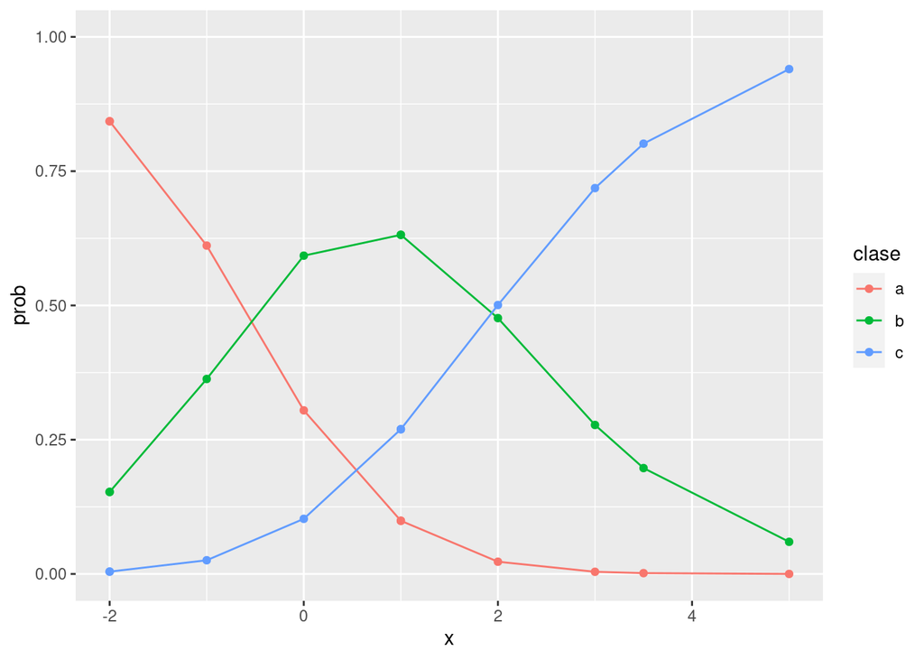

```r
probas_mod_tbl |>
  ggplot(aes(x = x, y = prob, colour = clase)) +
  geom_point() + geom_line() + ylim(c(0,1))
```

**Pregunta 9**: ¿qué pasa con estas probabildades si pones un valor de regularización considerablemente más alto? ¿Por qué este modelo que considera tres predictores lineales separados puede ser que no funcione bien sin regularización?

Checa los coeficientes de los predictores lineales aquí:

```r
get_weights(modelo_mult)
```

```
[[1]]
          [,1]        [,2]      [,3]
[1,] -1.248515 -0.06176639 0.8396729

[[2]]
[1]  0.1405595  0.8061767 -0.9467361
```